[output not shown]

```r
library(tidyverse)
```

```r
library(readxl)
library(gplots)
```

$\underline{\text{Exercice.13}}$

```r
# Creation d'un data-frame "acteur"
Mort.à <- c(93,53,72,68,68,53)
Années.de.carrière <- c(66,25,48,37,31,32)
Nombre.de.films <- c(211,58,98,140,74,81)
Prénom <- c("Michel","André","Jean","Louis","Lino","Jacques")
Nom <- c("Galabru","Raimbourg","Gabin","De Funès","Ventura","Villeret")
Date.du.décès <- c("04-01-2016","23-09-1970","15-10-1976","27-01-1983","22-10-1987","28-01-2005")
data.acteur <- data.frame(Mort.à,Années.de.carrière,Nombre.de.films,Prénom,Nom,Date.du.décès)
 #utilisation d'un dplyer pour renommer la premiere variable
data.acteur.r <- rename(data.acteur,"Age.du.décès"=Mort.à)
# extraction de la colonne Prénom
prenom.extract <- data.acteur$Prénom
data.acteur.arrange <- arrange(data.acteur.r,Age.du.décès)
```

$\underline{\text{Exercice.14}}$

$\textbf{Question 1.}$

```r
w <-read.delim(file="data/fromages1-TP-M1.txt")
```

$\textbf{Question 2.}$

```r
w <- rename(w,"mean.score"=Y,"c.a.a"=X1,"c.h.s"=X2,"c.a.l"=X3)
w$X1
```

$\textbf{Question 3.}$:Les caracteristiques de w:

```r
print(w)
```

```
##    mean.score c.a.a  c.h.s c.a.l
## 1        12.3 4.543  3.135  0.86
## 2        20.9 5.159  5.043  1.53
## 3        39.0 5.366  5.438  1.57
## 4        47.9 5.759  7.496  1.81
## 5         5.6 4.663  3.807  0.99
## 6        25.9 5.697  7.601  1.09
## 7        37.3 5.892  8.726  1.29
## 8        21.9 6.078  7.966  1.78
## 9        18.1 4.898  3.850  1.29
## 10       21.0 5.242  4.174  1.58
## 11       34.9 5.740  6.142  1.68
## 12       57.2 6.446  7.908  1.90
## 13        0.7 4.477  2.996  1.06
## 14       25.9 5.236  4.942  1.30
```

[output cut: 16 more lines]

$\textbf{Question 4}$:Les parametres statistiques des variables

```r
summary(w)
```

```
##    mean.score        c.a.a           c.h.s            c.a.l
##  Min.   : 0.70   Min.   :4.477   Min.   : 2.996   Min.   :0.860
##  1st Qu.:13.55   1st Qu.:5.237   1st Qu.: 3.978   1st Qu.:1.250
##  Median :20.95   Median :5.425   Median : 5.329   Median :1.450
##  Mean   :24.53   Mean   :5.498   Mean   : 5.942   Mean   :1.442
##  3rd Qu.:36.70   3rd Qu.:5.883   3rd Qu.: 7.575   3rd Qu.:1.667
##  Max.   :57.20   Max.   :6.458   Max.   :10.199   Max.   :2.010
```

$\textbf{Question 5.}$:

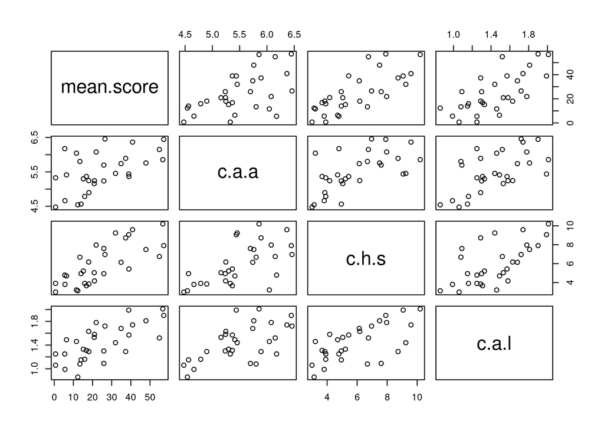

```r
pairs(w)
```

la commande pairs permet de tracer une nuage de point pour chaque variable afin de voir les differentes correlations qui peuvent exister

$\textbf{Question 6.}$:Construction d’une nouvelle data frame

```r
nv.c.a.a <- c(w$c.a.a[w$c.a.a > 5.1],rep(NA,6))
nv.c.a.l <- c(w$c.a.l[w$c.a.l < 1.77],rep(NA,5))
ww <- data.frame(w$mean.score,nv.c.a.a,w$c.h.s,nv.c.a.l)
ww <- rename(ww,"mean.score"=w.mean.score,"c.a.a"=nv.c.a.a,"c.h.s"=w.c.h.s,"c.a.l"=nv.c.a.l)
```

$\textbf{Question 7.}$: Les caracteristiques de ww

```r
print(ww)
```

```
##    mean.score c.a.a  c.h.s c.a.l
## 1        12.3 5.159  3.135  0.86
## 2        20.9 5.366  5.043  1.53
## 3        39.0 5.759  5.438  1.57
## 4        47.9 5.697  7.496  0.99
## 5         5.6 5.892  3.807  1.09
## 6        25.9 6.078  7.601  1.29
## 7        37.3 5.242  8.726  1.29
## 8        21.9 5.740  7.966  1.58
## 9        18.1 6.446  3.850  1.68
## 10       21.0 5.236  4.174  1.06
## 11       34.9 6.151  6.142  1.30
## 12       57.2 6.365  7.908  1.52
## 13        0.7 5.412  2.996  1.74
## 14       25.9 5.247  4.942  1.16
```

[output cut: 16 more lines]

$\textbf{Question 8.}$: Les parametres statistiques de la variable ww

```r
summary(ww)
```

```
##    mean.score        c.a.a           c.h.s            c.a.l
##  Min.   : 0.70   Min.   :5.159   Min.   : 2.996   Min.   :0.860
##  1st Qu.:13.55   1st Qu.:5.356   1st Qu.: 3.978   1st Qu.:1.160
##  Median :20.95   Median :5.718   Median : 5.329   Median :1.310
##  Mean   :24.53   Mean   :5.709   Mean   : 5.942   Mean   :1.351
##  3rd Qu.:36.70   3rd Qu.:6.052   3rd Qu.: 7.575   3rd Qu.:1.530
##  Max.   :57.20   Max.   :6.458   Max.   :10.199   Max.   :1.740
##                  NA's   :6                        NA's   :5
```

$\underline{\text{Exercice 15.}}$

$1.\\$

```r
data(airquality) # charger les donées airquality
df.airquality <- data.frame(airquality)
```

$2. \text{Affichage des noms des variables}$

```r
names(df.airquality)
```

```
## [1] "Ozone"   "Solar.R" "Wind"    "Temp"    "Month"   "Day"
```

$3 .\text{nombre de ligne et de colonne}$

```r
nrow(df.airquality)
```

```
## [1] 153
```

```r
ncol(df.airquality)
```

```
## [1] 6
```

$4 .\text{Les parametres statistiques}$

```r
summary(df.airquality)
```

```
##      Ozone           Solar.R           Wind             Temp
##  Min.   :  1.00   Min.   :  7.0   Min.   : 1.700   Min.   :56.00
##  1st Qu.: 18.00   1st Qu.:115.8   1st Qu.: 7.400   1st Qu.:72.00
##  Median : 31.50   Median :205.0   Median : 9.700   Median :79.00
##  Mean   : 42.13   Mean   :185.9   Mean   : 9.958   Mean   :77.88
##  3rd Qu.: 63.25   3rd Qu.:258.8   3rd Qu.:11.500   3rd Qu.:85.00
##  Max.   :168.00   Max.   :334.0   Max.   :20.700   Max.   :97.00
##  NA's   :37       NA's   :7
##      Month            Day
##  Min.   :5.000   Min.   : 1.0
##  1st Qu.:6.000   1st Qu.: 8.0
##  Median :7.000   Median :16.0
##  Mean   :6.993   Mean   :15.8
##  3rd Qu.:8.000   3rd Qu.:23.0
##  Max.   :9.000   Max.   :31.0
##
```

$5 .\text{representation de la boite a moustache}$

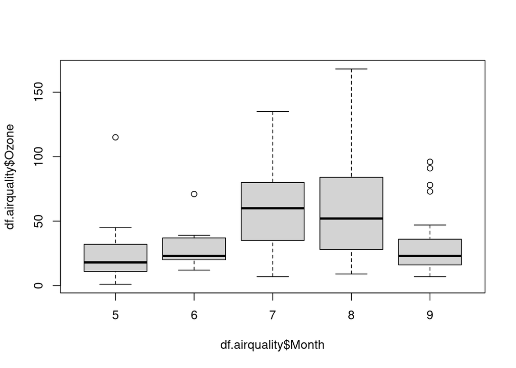

```r
boxplot(df.airquality$Ozone~df.airquality$Month)
```

$6 .\text{Creation d'une variable qualitative "saison"}$

```r
saison <-factor(df.airquality$Month,levels=c(5:9))
levels(saison)[levels(saison)==5] <- "printemps"
levels(saison)[levels(saison)==6] <- "éte"
levels(saison)[levels(saison)==7] <- "éte"
levels(saison)[levels(saison)==8] <- "éte"
levels(saison)[levels(saison)==9] <- "automne"
df.airquality$season = saison
```

$7 .$

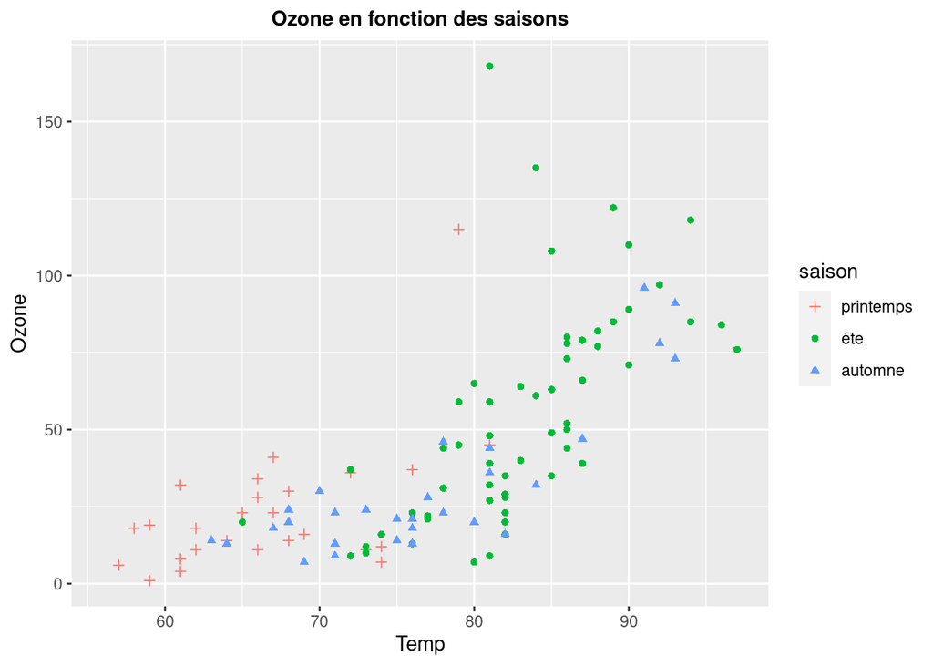

```r
g <- ggplot(data = df.airquality) +
  geom_point(mapping = aes(x =Temp, y = Ozone, shape = saison,color=saison)) +
  scale_shape_manual(values=c(3, 16, 17))+
  ggtitle("Ozone en fonction des saisons")
g + theme (plot.title = element_text(size=11,face="bold",hjust = 0.5))
```

$\underline{\text{Exercice 16}}$

$\text{1.Simulation de 100 valeurs suivant une loi normale}$

```r
n <- 100
e <- rnorm(n,0,25)
```

$2.$ Pour tout $i\in{1,\ldots,100}$,on pose $y_{i}=1.7 + 2.1 i + e_{i}\\$

```r
i <- c(1:100)
yi <- 1.7 + 2.1 * i + e[i]
```

2.a et 2.b: $\text{representation d'un nuage de point et une droite} \ (i,y_{i})$

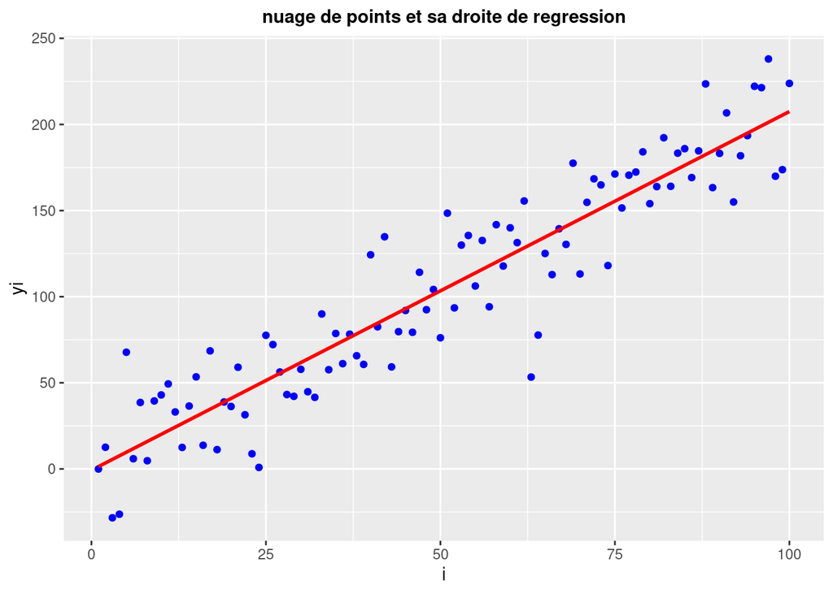

```r
data.f <- data.frame(i,yi)
g <- ggplot(data = data.f) +
geom_point(mapping = aes(x = i, y = yi),colour="blue") +
geom_smooth(mapping = aes(x = i, y = yi),se = FALSE,colour="red",fill="red",method = lm) +
ggtitle("nuage de points et sa droite de regression")
g + theme (plot.title = element_text(size=11,face="bold",hjust = 0.5))
```

$\underline{\text{Exercice 17}}$

```r
# Creation d'une matrice
ligne1 <- c(68,119,26,7)
ligne2 <- c(15,54,14,10)
ligne3 <- c(5,29,14,16)
ligne4 <- c(20,84,17,94)
mat <- matrix(c(ligne1,ligne2,ligne3,ligne4),nrow = 4,ncol=4,byrow = T,dimnames = list(c("marron","noisette","vert","bleu"),c("brun", "chatin","roux","blond")))
```

$\textbf{2. Calculer la matrice des fréquences (arrondit au 100ème près)}$

```r
matfreq <- mat / sum(mat)
round(matfreq*100,2)
```

```
##           brun chatin roux blond
## marron   11.49  20.10 4.39  1.18
## noisette  2.53   9.12 2.36  1.69
## vert      0.84   4.90 2.36  2.70
## bleu      3.38  14.19 2.87 15.88
```

3. les lois marginales (nommer c pour le vecteur colonne et r pour le vecteur ligne)

```r
l <- round(apply(matfreq,1,sum),2)
c <- round(apply(matfreq,2,sum),2)
```

4.Profils lignes

```r
L <- round(sweep(mat,1,rowSums(mat),'/'),2)
```

5.Profils colonnes

```r
C <- round(sweep(mat,2,colSums(mat),'/'),2)
```

6. La distance de chi-deux entre les profils lignes

```r
d.chi <- 0
distancechideux <- function(L){
  for(i in 1:nrow(L)-1){

    d.chi <- d.chi + sum(((L[i,] - L[i+1,]) ^ 2) /c)
  }
  return (d.chi)
}
```

7. la matrice des taux de liaison

```r
t <- round((matfreq - (l%*%t(c))) / (l%*%t(c)),2)
```

$\textbf{Exercice 18}$

```r
tableau <- matrix(c(290,410,110,190), ncol=2, byrow=TRUE)
colnames(tableau) <- c("Bleu","Brun")
rownames(tableau) <- c("Celib","Marie")
tableau <- as.table(tableau)
```

```r
print(tableau)
```

```
##       Bleu Brun
## Celib  290  410
## Marie  110  190
```

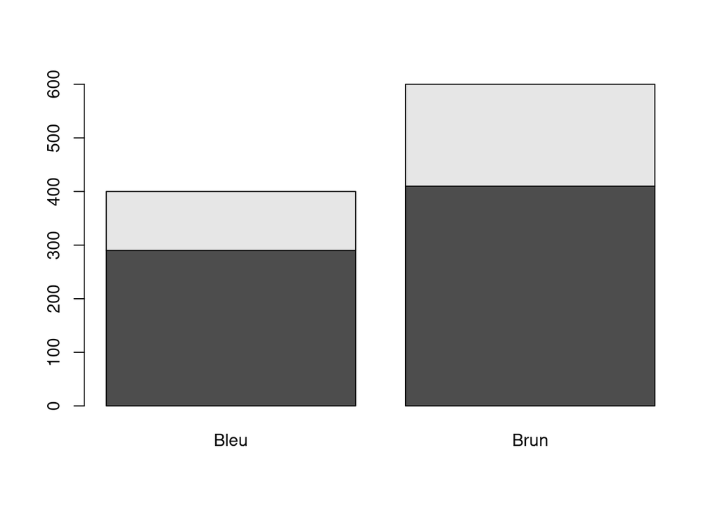

```r
barplot(tableau)
```

```r
n <- margin.table(tableau)
m1 <- margin.table(tableau,1)
m2 <- margin.table(tableau,2)
prop.table(tableau)
```

```
##       Bleu Brun
## Celib 0.29 0.41
## Marie 0.11 0.19
```

4. Le test du chi-deux

```r
chisq.test(tableau)
```

```
##
##  Pearson's Chi-squared test with Yates' continuity correction
##
## data:  tableau
## X-squared = 1.7907, df = 1, p-value = 0.1808
```

4.a

```r
tab0 <- as.array(m1) %*% t(as.array(m2))/n
tab0 <- as.table(tab0)
```

5.b

```r
tab1 <- as.matrix(tableau)
tab1[2,1] <- tab1[1,1] + tab1[2,1]
tab1[1,1] <- 0
tab1[1,2] <- tab1[1,2] + tab1[2,2]
tab1[2,2] <- 0
tab1tab <- as.matrix(tab1)
chisq.test(tab1tab)
```

```
##
##  Pearson's Chi-squared test with Yates' continuity correction
##
## data:  tab1tab
## X-squared = 995.84, df = 1, p-value < 2.2e-16
```

$\underline{\text{6. Test de khi-deux sur quelques echantillons de R}}$

```r
data(HairEyeColor)
dfH <- as.data.frame(HairEyeColor)
tH <- xtabs(Freq~Hair+Eye,dfH)
chisq.test(tH)
```

```
##
##  Pearson's Chi-squared test
##
## data:  tH
## X-squared = 138.29, df = 9, p-value < 2.2e-16
```

```r
data(Titanic)
dfT <- as.data.frame(Titanic)
dfTtab <- xtabs(Freq~Sex+Survived,dfT)
chisq.test(dfTtab)
```

```
##
##  Pearson's Chi-squared test with Yates' continuity correction
##
## data:  dfTtab
## X-squared = 454.5, df = 1, p-value < 2.2e-16
```

```r
data(UCBAdmissions)
dfU <- as.data.frame(UCBAdmissions)
dfUtab <- xtabs(Freq~Admit+Gender,dfU)
chisq.test(as.table(dfUtab))
```

```
##
##  Pearson's Chi-squared test with Yates' continuity correction
##
## data:  as.table(dfUtab)
## X-squared = 91.61, df = 1, p-value < 2.2e-16
```

$\textbf{Exercice 19}$

```r
data(cars)
# regression lineaire
reg <- lm(dist~speed,cars)
summary(reg)
```

```
##
## Call:
## lm(formula = dist ~ speed, data = cars)
##
## Residuals:
##     Min      1Q  Median      3Q     Max
## -29.069  -9.525  -2.272   9.215  43.201
##
## Coefficients:
##             Estimate Std. Error t value Pr(>|t|)
## (Intercept) -17.5791     6.7584  -2.601   0.0123 *
## speed         3.9324     0.4155   9.464 1.49e-12 ***
## ---
## Signif. codes:  0 '***' 0.001 '**' 0.01 '*' 0.05 '.' 0.1 ' ' 1
##
## Residual standard error: 15.38 on 48 degrees of freedom
## Multiple R-squared:  0.6511, Adjusted R-squared:  0.6438
## F-statistic: 89.57 on 1 and 48 DF,  p-value: 1.49e-12
```

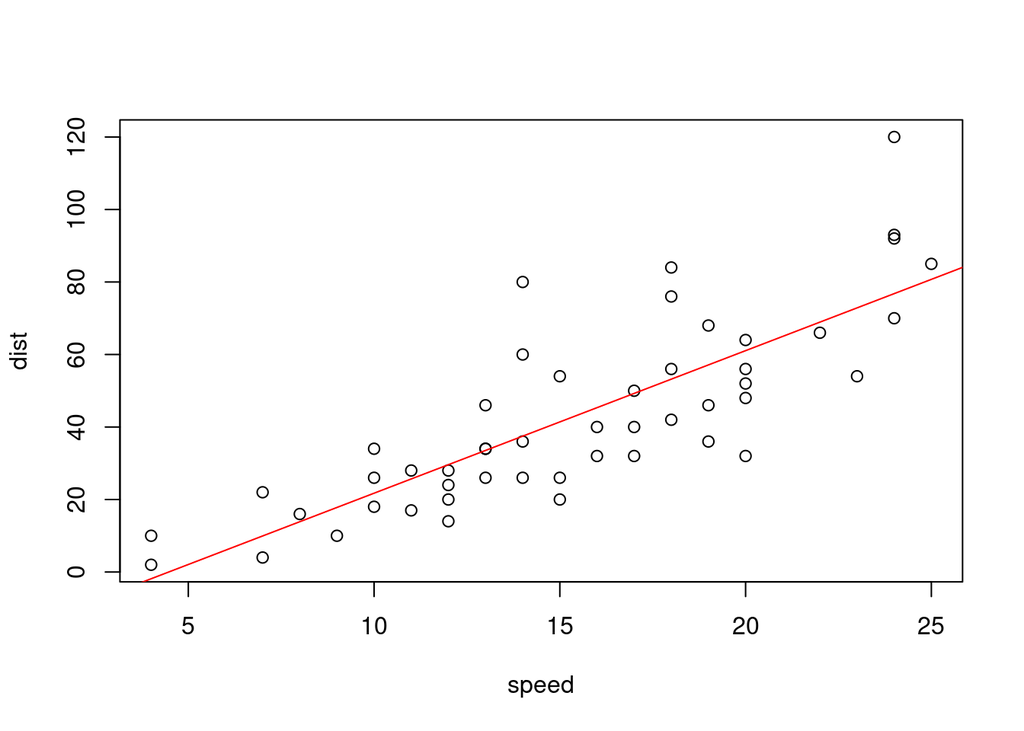

```r
plot(cars)
abline(reg,col="red")
```

```r
#abline(reg$coefficients,col="yellow")
```

$\text{19.a: La valeur prédite pour une vitesse de 20}$

```r
predict(reg,newdata = data.frame(speed=20))
```

```
##        1
## 61.06908
```

$\underline{\text{Exercice 20}}$

$\text{declaration des données}$

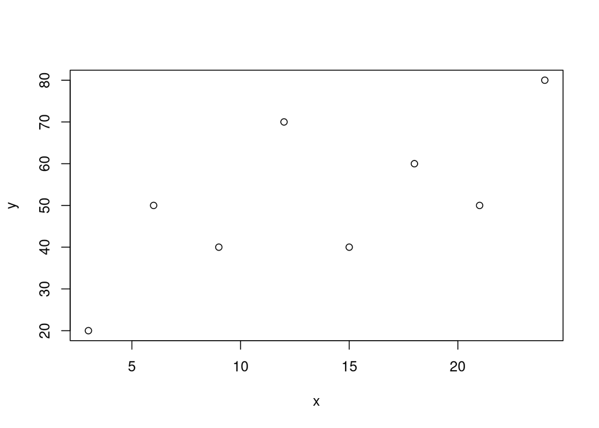

```r
x <- c(3,6,9,12,15,18,21,24)
y <- c(20,50,40,70,40,60,50,80)
reg1 <- lm(x~y)
plot(x,y)
abline(reg1)
```

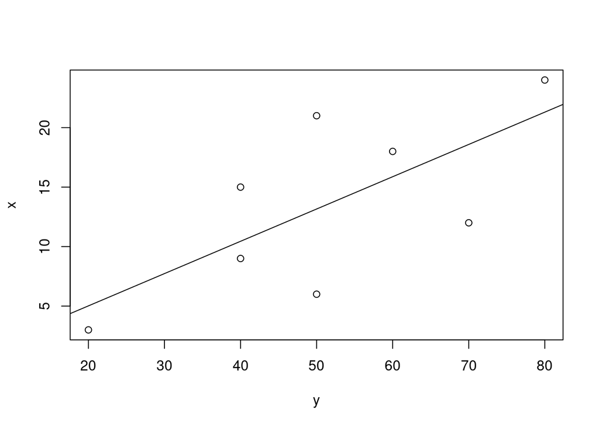

```r
reg2 <- lm(x~y)
plot(y,x)
abline(reg2)
```

le coefficient de correlation entre x et y

```r
cor(x,y)
```

```
## [1] 0.6961075
```

```r
fisher.test(x,y)
```

```
##
##  Fisher's Exact Test for Count Data
##
## data:  x and y
## p-value = 1
## alternative hypothesis: two.sided
```

$\underline{\text{Exercice 21}}$

```r
y <- c(85,70,100,140,115,105)
x1 <- c(3,5,9,12,14,17)
x2 <- c(11,14,15,16,19,23)
regm <- lm(y~x1+x2)
anova(regm)
```

```
## Analysis of Variance Table
##
## Response: y
##           Df  Sum Sq Mean Sq F value  Pr(>F)
## x1         1 1284.03 1284.03  31.821 0.01102 *
## x2         1 1532.42 1532.42  37.977 0.00860 **
## Residuals  3  121.06   40.35
## ---
## Signif. codes:  0 '***' 0.001 '**' 0.01 '*' 0.05 '.' 0.1 ' ' 1
```

$\underline{\text{Exercice 22}}$

```r
# load data
data <- read_excel("data/Donnees-TP2-M1-MIASHS.xls")
summary(data)
```

```
##      Sexe                Age         EtatCivil            Nbenfant
##  Length:168         Min.   :25.00   Length:168         Min.   :0.00
##  Class :character   1st Qu.:37.00   Class :character   1st Qu.:1.00
##  Mode  :character   Median :41.00   Mode  :character   Median :2.00
##                     Mean   :41.99                      Mean   :1.72
##                     3rd Qu.:49.25                      3rd Qu.:2.00
##                     Max.   :57.00                      Max.   :5.00
##    Diplome            Anciennete       Salaire      Satisfaction
##  Length:168         Min.   : 1.00   Min.   :1200   Min.   : 3.85
##  Class :character   1st Qu.:10.00   1st Qu.:1650   1st Qu.:13.84
##  Mode  :character   Median :15.00   Median :1720   Median :19.17
##                     Mean   :16.55   Mean   :1778   Mean   :20.43
##                     3rd Qu.:24.25   3rd Qu.:1908   3rd Qu.:28.31
##                     Max.   :34.00   Max.   :2200   Max.   :38.45
##      Stress        EstimeSoi     AvisReforme
##  Min.   : 3.70   Min.   : 3.54   Length:168
##  1st Qu.:15.19   1st Qu.:14.03   Class :character
##  Median :18.19   Median :19.68   Mode  :character
##  Mean   :18.20   Mean   :21.08
##  3rd Qu.:21.11   3rd Qu.:29.84
##  Max.   :31.84   Max.   :42.15
```

$\text{Tableau de contigence}$

```r
datavq <- subset(data,select=c(Sexe,EtatCivil,Diplome,AvisReforme))
tabc1 <- table(datavq)
tabc2 <- round(tabc1/sum(tabc1),2)
tabc3 <- tabc2*100
```

$\text{Representation graphique}$

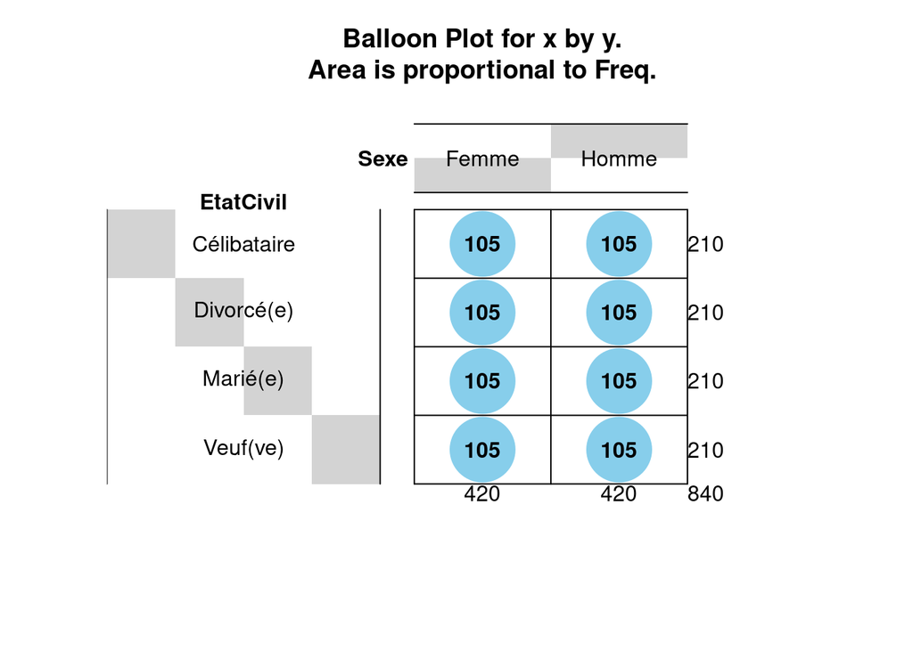

```r
balloonplot(tabc1)
```

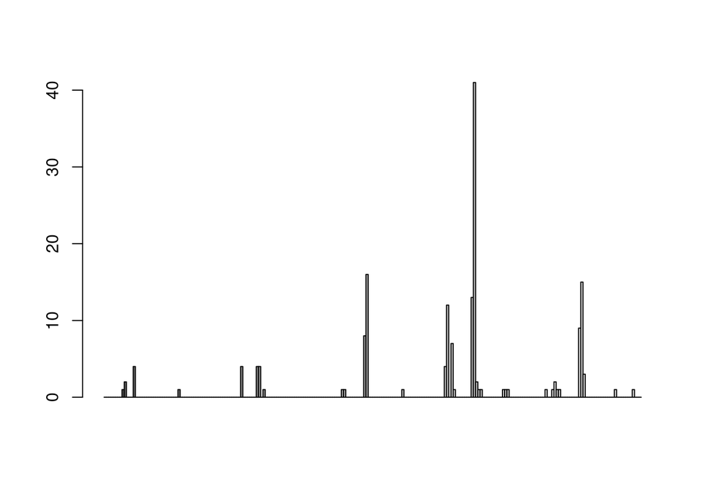

```r
barplot(as.matrix(tabc1),beside = TRUE)
```

$\textbf{Croisement qualitatif vs qualitatif}$

```r
# distribution marginale
matfreq <- tabc1 / sum(tabc1)
dl <- round(apply(matfreq,1,sum),2)
dl
```

```
## Femme Homme
##  0.32  0.68
```

```r
dc <- round(apply(matfreq,2,sum),2)
dc
```

```
## Célibataire  Divorcé(e)    Marié(e)    Veuf(ve)
##        0.14        0.08        0.74        0.04
```

```r
# distribution conditionnelle
DC <- sweep(tabc1,2,colSums(tabc1),"/")
# test de khi-deux
dfse <- subset(data,select = c(Sexe,EtatCivil))
tabdfse <- table(dfse)
chisq.test(tabdfse)
```

```
##
##  Pearson's Chi-squared test
##
## data:  tabdfse
## X-squared = 5.6972, df = 3, p-value = 0.1273
```

```r
# p-value > 0.05 donc pas de dependance significative entre les deux variables
```

$\textbf{Croisement qualitatif vs quantitatif}$

```r
# Resumé de la variable stress
s <- data$Stress
summary(s)
```

```
##    Min. 1st Qu.  Median    Mean 3rd Qu.    Max.
##    3.70   15.19   18.19   18.20   21.11   31.84
```

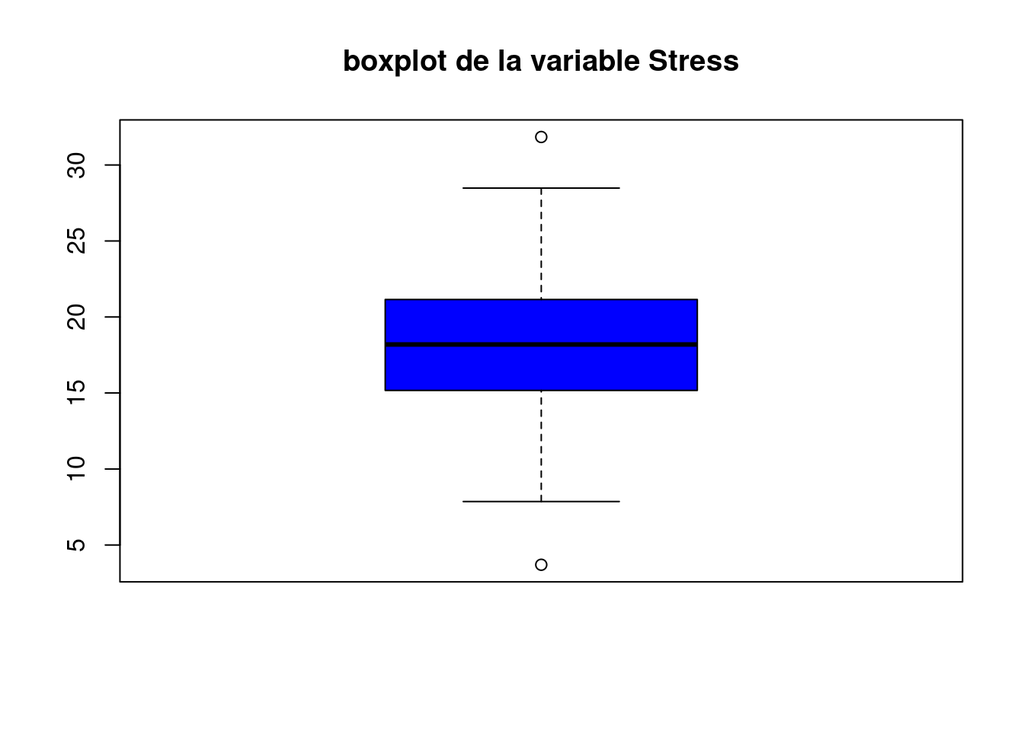

```r
boxplot(s,col="blue",main="boxplot de la variable Stress")
```

```r
datf <- subset(data,select = c(Stress,EtatCivil))
tabSE <- table(datf) # effectif
head(tabSE / sum(tabSE),6)
```

```
##                   EtatCivil
## Stress             Célibataire  Divorcé(e)    Marié(e)    Veuf(ve)
##   3.7              0.000000000 0.000000000 0.005952381 0.000000000
##   7.86             0.005952381 0.000000000 0.000000000 0.000000000
##   8                0.000000000 0.005952381 0.000000000 0.000000000
##   8.34             0.000000000 0.000000000 0.005952381 0.000000000
##   9.12             0.000000000 0.000000000 0.000000000 0.005952381
##   9.18000000000001 0.005952381 0.000000000 0.000000000 0.000000000
```

```r
head(round(tabSE / sum(tabSE),2) * 100)
```

```
##                   EtatCivil
## Stress             Célibataire Divorcé(e) Marié(e) Veuf(ve)
##   3.7                        0          0        1        0
##   7.86                       1          0        0        0
##   8                          0          1        0        0
##   8.34                       0          0        1        0
##   9.12                       0          0        0        1
##   9.18000000000001           1          0        0        0
```

```r
chisq.test(tabSE)
```

```
##
##  Pearson's Chi-squared test
##
## data:  tabSE
## X-squared = 471.47, df = 465, p-value = 0.4078
```

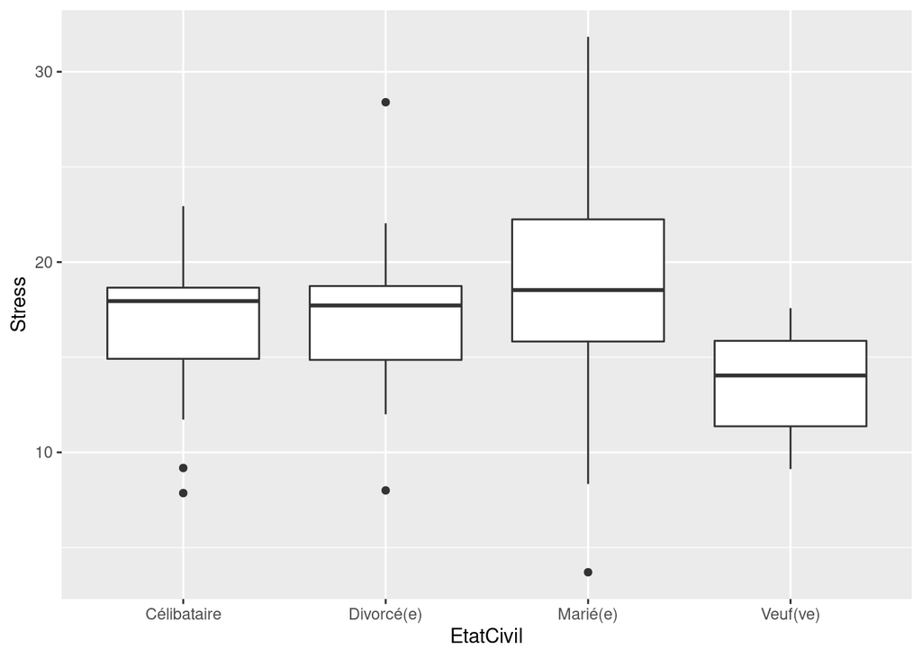

```r
ggplot(datf,aes(EtatCivil, Stress,fill = Stress)) + geom_boxplot()
```